# How to Use the AnalyzeVWC package to analyze high-resolution volumetric water content data.

Aurelie Poncet

Last edited on: 2021-01-26

# Introduction

```r
# Import required packages
library(AnalyzeVWC)
library(imputeTS)
library(tidyr)
library(rlist)
library(dplyr)
library(signal)
library(tibble)
library(lubridate)
library(ggplot2)
```

# Dataset 1

## Raw Data

Import the data.

```r
data(dataset1)
```

Dataset1 has 20208 rows and 5 columns.

```r
head(dataset1)
```

```
##          site     treatment           date.time sensor_depth  vwc
## 402650 Site A No Cover Crop 2020-05-08 17:00:00          -15  6.3
## 402651 Site A No Cover Crop 2020-05-08 17:00:00          -80 10.9
## 402652 Site A No Cover Crop 2020-05-08 17:00:00          -45 16.8
## 402653 Site A No Cover Crop 2020-05-08 18:00:00          -15  6.3
## 402654 Site A No Cover Crop 2020-05-08 18:00:00          -80 10.8
## 402655 Site A No Cover Crop 2020-05-08 18:00:00          -45 16.7
```

Data were collected in 2020 at the following coordinates: longitude = -85.4193 and latitude = 31.3995 [WGS84]. The experimental site was name *Site A* and data were collected across two treatments: *No Cover Crop, Cover Crop*. TDR sensors were placed at *-15, -80, -45* to measure volumetric water content in each treatment.

Data types are the following. Note that the timestamps are provided in the POSIXlt POSIXt format. Data were collected from 2020-05-08 to 2020-10-07.

```r
sapply(dataset1, class)
```

```
## $site
## [1] "character"
##
## $treatment
## [1] "character"
##
## $date.time
## [1] "POSIXlt" "POSIXt"
##
## $sensor_depth
## [1] "numeric"
##
## $vwc
## [1] "numeric"
```

Raw data plot:

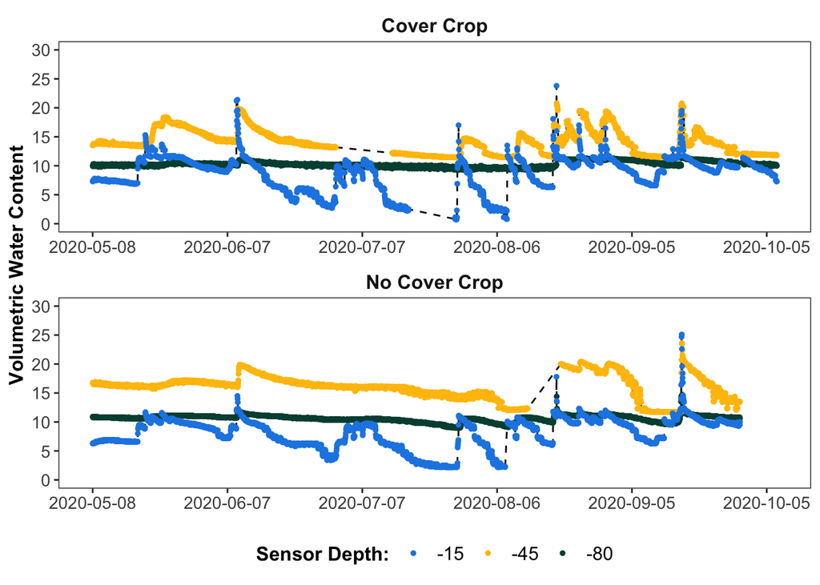

```r
## Format data for plotting
data.plot <- dataset1[order(dataset1$site, dataset1$treatment, dataset1$sensor_depth, dataset1$date.time),] # order observations
data.plot$relativetime <- as.numeric(difftime(data.plot$date.time, min(data.plot$date.time), unit="hours"))+1 # calculate relative time

## Plot raw data
ggplot(data=data.plot, aes(x=relativetime, y=vwc, group=as.character(sensor_depth)))+
  geom_line(size=0.5, linetype="dashed")+
  geom_point(size=1, aes(color=as.character(sensor_depth))) +
  ylab("Volumetric Water Content")+
  facet_wrap(~treatment, ncol=1, scales="free")+
  scale_color_manual(values=c("#1E88E5","#FFC107","#004D40"),name="Sensor Depth:")+
  scale_y_continuous(limits=c(0,5*ceiling(max(data.plot$vwc/5))), breaks = seq(0,5*ceiling(max(data.plot$vwc/5)),by=5))+
  scale_x_continuous(limits=c(1,max(data.plot$relativetime)), breaks=seq(1,max(data.plot$relativetime),by=24*30), label = as.Date(as.character(seq(min(data.plot$date.time),max(data.plot$date.time),by="30 days"))))+
  theme
```

## Identify Infiltration Events

### Interpolate Missing Volumetric Water Content Values in Deeper Depths

The `InterpolateMissingVWCData()` function allows the user to interpolate missing volumetric water content data up to a user defined number of time periods, if little variability among the measurements is expected.

For this example, we chose to interpolate the missing volumetric water data if:

- no more than 4 hours of data are missing at 15 cm depths,
- no more than 12 hours of data are missing at 45 cm depths,
- independently from the number of hours missing at 80 cm depth.

```r
interpolated1 <- InterpolateMissingVWCData(data = dataset1, temp.resolution = 1, temp.unit = "hours", time.col = 3, response.col = 5, design.col = c(1,2), depth.col = 4, depths.values = c(-15, -45, -80), missing.max.time.by.depth = c(4,12,NA))
```

### Calculate Cumulative Depth of Water Across the Soil Profile

The cumulative depth of water content is calculated using a weighted average of volumetric water content data. Coefficients of the weighted average calculation are determined based on the installation depth of the sensors and the user-defined soil profile boundaries, depth increments, and thickness of soil affecting the sensor measurement.

For this example, sensors were placed at 15, 45, and 80 cm depth across the profile. We want to calculate water availability from 10 and 85 cm depth. The weighted average coefficients are calculated using a 5 cm increment. Sensors were placed vertically in the soil and sensor height was 10 cm.

```r
cumuldepth1 <- CalculateCumulativeWaterDepth(data = interpolated1, design.col = c(1,2), time.col = 3, depth.col = 4, response.col = 5, profile.min = -85, profile.max = -10, increment = 5, sensor.height = 10, divideby100 = T)
```

The weighted average coefficients defined to calculate available water from 10 to 85 cm depth can be extracted from the results as follow. The `layer.low` and `layer.high` columns indicate the bottom and top depth of the soil layer. Values in `D*` columns correspond to the weighted coefficient associated with each depth for each layer. The provided depths values were ordered from the lowest to the highest value, and D1 correspons to the deepest sensor depth if negative depth values were provided, and to the shallowest sensor depth if positive values were provided.

```r
print(cumuldepth1[[1]])
```

```
##    layer.low layer.high D1 D2 D3 weight
## 1        -85        -80  1  0  0      1
## 2        -80        -75  1  0  0      1
## 3        -75        -70  5  1  0      6
## 4        -70        -65  4  2  0      6
## 5        -65        -60  3  3  0      6
## 6        -60        -55  2  4  0      6
## 7        -55        -50  1  5  0      6
## 8        -50        -45  0  1  0      1
## 9        -45        -40  0  1  0      1
## 10       -40        -35  0  4  1      5
## 11       -35        -30  0  3  2      5
## 12       -30        -25  0  2  3      5
## 13       -25        -20  0  1  4      5
## 14       -20        -15  0  0  1      1
## 15       -15        -10  0  0  1      1
```

The calculated water availability can be extracted from the results as follow. Results are provided in the `cumul.depth` column.

```r
cumuldepth.values1 <- cumuldepth1[[2]]
head(cumuldepth.values1)
```

```
##     site  treatment                time   -80   -45   -15 cumul.depth
## 1 Site A Cover Crop 2020-05-08 17:00:00 0.100 0.135 0.073       8.098
## 2 Site A Cover Crop 2020-05-08 18:00:00 0.099 0.136 0.073       8.107
## 3 Site A Cover Crop 2020-05-08 19:00:00 0.102 0.137 0.075       8.247
## 4 Site A Cover Crop 2020-05-08 20:00:00 0.103 0.136 0.075       8.237
## 5 Site A Cover Crop 2020-05-08 21:00:00 0.102 0.138 0.075       8.280
## 6 Site A Cover Crop 2020-05-08 22:00:00 0.102 0.136 0.074       8.195
```

Plot of available water data:

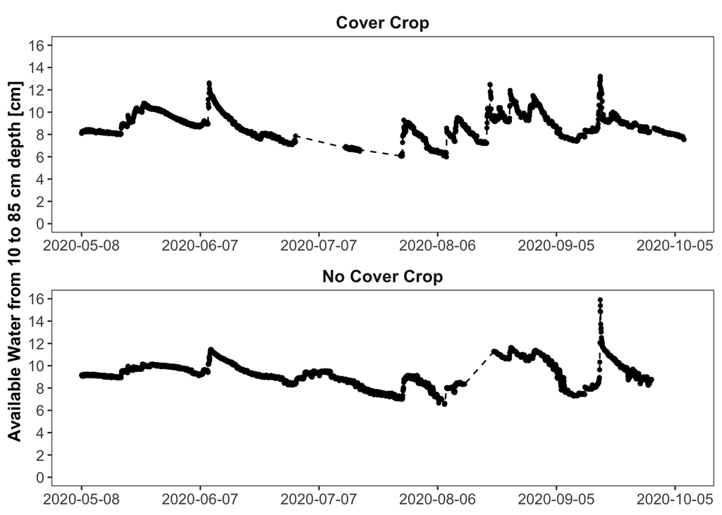

```r
## Format data for plotting
data.plot <- cumuldepth.values1[order(cumuldepth.values1$site, cumuldepth.values1$treatment, cumuldepth.values1$time),] # order observations
data.plot$relativetime <- as.numeric(difftime(data.plot$time, min(data.plot$time), unit="hours"))+1 # calculate relative time

## Plot raw data
ggplot(data=data.plot[!is.na(data.plot$cumul.depth),], aes(x=relativetime, y=cumul.depth))+
  geom_line(size=0.5, linetype="dashed")+
  geom_point(size=1) +
  ylab("Available Water from 10 to 85 cm depth [cm]")+
  facet_wrap(~treatment, ncol=1, scales="free")+
  scale_y_continuous(limits=c(0,2*ceiling(max(data.plot$cumul.depth[!is.na(data.plot$cumul.depth)]/2))), breaks = seq(0,2*ceiling(max(data.plot$cumul.depth[!is.na(data.plot$cumul.depth)]/2)),by=2))+
  scale_x_continuous(limits=c(1,max(data.plot$relativetime)), breaks=seq(1,max(data.plot$relativetime),by=24*30), label = as.Date(as.character(seq(min(data.plot$time),max(data.plot$time),by="30 days"))))+
  theme
```

### Divide Cumulative Depth of Water Data into Contignuous Chunks

The time series representing the amount of available water in the soil profile must be divided into chunks of continuous data to facilitate data handling and identification of infiltration peaks. In this example, we decided to only keep chunks with at least 12 hours of continuous data.

```r
cumul.chunks1 <- DivideIntoChunks(data = cumuldepth.values1, design.col = c(1:2), time.col = 3, response.col = 7, min.successive.obs=12, time.interval = 1, time.unit = "hour")
```

Plot identified chunks of data:

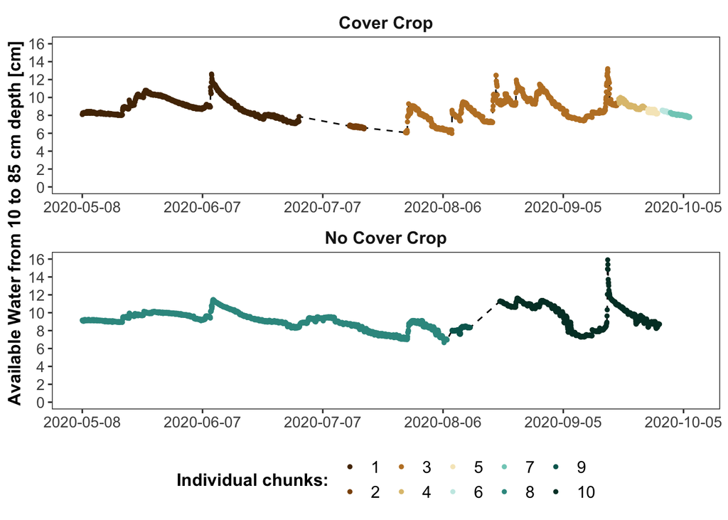

```r
# format data for plotting
data.plot <- c()
counter <- 1
for(item in 1:length(cumul.chunks1)){ # begin iteration over items
  for (chunk in 1:length(cumul.chunks1[[item]])){ # begin iteration over chunks in item

    if(length(data.plot)==0){
      data.plot <- data.frame(cumul.chunks1[[item]][chunk])
      data.plot$chunkid <- counter; counter <- counter + 1
    } else {
      temp <- data.frame(cumul.chunks1[[item]][chunk])
      temp$chunkid <- counter
      counter <- counter + 1; data.plot <- rbind(data.plot, temp)
    }

  } # end iteration over chunks in item
} # end iteration over items

data.plot$relativetime <- as.numeric(difftime(data.plot$time, min(data.plot$time), unit="hours"))+1 # calculate relative time
data.plot <- within(data.plot, chunkid <- as.factor(chunkid))

# plot results
ggplot(data=data.plot, aes(x=relativetime, y=cumul.depth, group=chunk))+
  geom_line(size=0.5, linetype="dashed")+
  geom_point(size=1, aes(color=chunkid)) +
  ylab("Available Water from 10 to 85 cm depth [cm]")+
  facet_wrap(~treatment, ncol=1, scales="free") +
  scale_color_manual(values=c("#543005","#8C510A","#BF812D","#DFC27D","#F6E8C3","#C7EAE5","#80CDC1","#35978F","#01665E","#003C30"), name = "Individual chunks:")+
  scale_y_continuous(limits=c(0,2*ceiling(max(data.plot$cumul.depth[!is.na(data.plot$cumul.depth)]/2))), breaks = seq(0,2*ceiling(max(data.plot$cumul.depth[!is.na(data.plot$cumul.depth)]/2)),by=2))+
  scale_x_continuous(limits=c(1,max(data.plot$relativetime)), breaks=seq(1,max(data.plot$relativetime),by=24*30), label = as.Date(as.character(seq(min(data.plot$time),max(data.plot$time),by="30 days"))))+
  theme
```

### Filter Data for High Frequency Noise

Data within each chunks can be filtered for high frequency noise using one or multiple 6-point Savitzky-Golay filters. In this example, we filter the collected data using two consecutive filters.

```r
filter.chunks1 <- FilterWCData(data=cumul.chunks1, response.col = 7, nb.gs.filters = 2)
```

The filtered water availability data can be extracted from the results as follow. Results are provided in the `cumul.filter` column. Note that the first and last 6 observations for each chunk have *NULL* `cumul.filter` values.

```r
example <- data.frame(filter.chunks1[[1]][1])
head(example[!is.na(example$cumul.filter),])
```

```
##      site  treatment                time  X.80  X.45  X.15 cumul.depth
## 7  Site A Cover Crop 2020-05-08 23:00:00 0.102 0.138 0.075       8.280
## 8  Site A Cover Crop 2020-05-09 00:00:00 0.103 0.136 0.075       8.237
## 9  Site A Cover Crop 2020-05-09 01:00:00 0.100 0.138 0.075       8.235
## 10 Site A Cover Crop 2020-05-09 02:00:00 0.100 0.138 0.076       8.255
## 11 Site A Cover Crop 2020-05-09 03:00:00 0.100 0.138 0.078       8.295
## 12 Site A Cover Crop 2020-05-09 04:00:00 0.103 0.138 0.076       8.322
##    cumul.filter
## 7      8.244798
## 8      8.239469
## 9      8.249676
## 10     8.268531
## 11     8.289095
## 12     8.300313
```

Plot filtered versus unfiltered data:

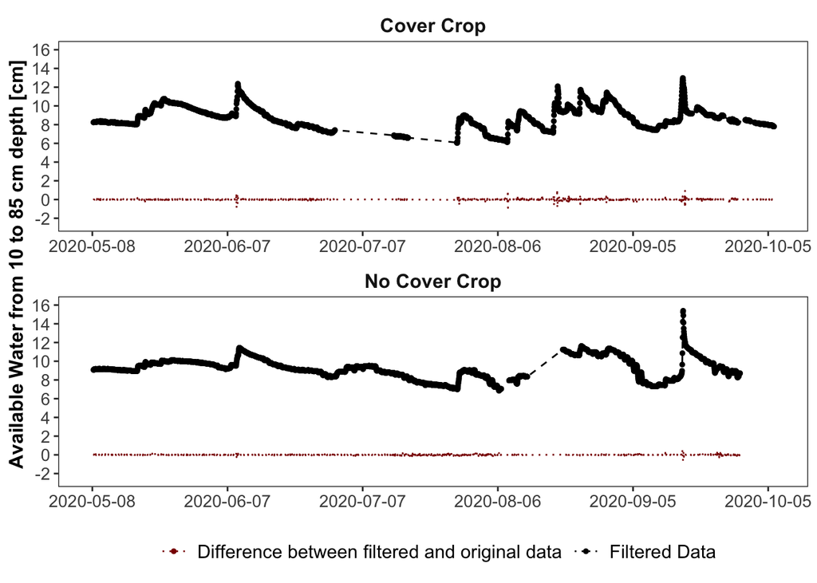

```r
# format data for plotting
data.plot <- c()
counter <- 1
for(item in 1:length(filter.chunks1)){ # begin iteration over items
  for (chunk in 1:length(filter.chunks1[[item]])){ # begin iteration over chunks in item

    if(length(data.plot)==0){
      data.plot <- data.frame(filter.chunks1[[item]][chunk])
    } else {
      temp <- data.frame(filter.chunks1[[item]][chunk])
      data.plot <- rbind(data.plot, temp)
    }

  } # end iteration over chunks in item
} # end iteration over items

data.plot$relativetime <- as.numeric(difftime(data.plot$time, min(data.plot$time), unit="hours"))+1 # calculate relative time
data.plot <- within(data.plot, delta.depth <- cumul.filter - cumul.depth) # calculate difference between original and filtered data
data.plot <- data.plot[!is.na(data.plot$delta.depth),]
data.plot <- within(data.plot, y <- cumul.filter - mean(cumul.filter))

# plot results
ggplot(data=data.plot[!is.na(data.plot$delta.depth),], aes(x=relativetime, y=cumul.filter))+
  geom_line(size=0.5, linetype="dashed")+
  geom_point(size=1, aes(color="Filtered Data")) +
  geom_line(size=0.5, linetype="dotted", aes(y=delta.depth, color = 'Difference between filtered and original data'))+
  ylab("Available Water from 10 to 85 cm depth [cm]")+
  facet_wrap(~treatment, ncol=1, scales="free") +
  scale_color_manual(values=c("darkred","black"), name = "")+
  scale_y_continuous(limits=c(-2.5,2*ceiling(max(data.plot$cumul.filter[!is.na(data.plot$cumul.filter)]/2))), breaks = seq(-2,2*ceiling(max(data.plot$cumul.filter[!is.na(data.plot$cumul.filter)]/2)),by=2))+
  scale_x_continuous(limits=c(1,max(data.plot$relativetime)), breaks=seq(1,max(data.plot$relativetime),by=24*30), label = as.Date(as.character(seq(min(data.plot$time),max(data.plot$time),by="30 days"))))+
  theme
```

### Identify Infiltration Events

Infiltration events were identified using the following methodology.

1. Data were filtered using a very rough Butterwork filter or order *n* (*n=2* by ddefault) and critical frequency *w* (*w=0.075* by default, and *w=0.065* in this example).
2. Local minimums and maximums were identified within the roughly filtered data.
3. Results were cleaned and corresponding true local minimums and maximums were identified in the original data.

```r
peaks1 <- IdentifyInfiltrationEvents(data = filter.chunks1, time.col = 3, design.col = c(1,2),
                                     response.col = 8, butter.n = 2, butter.w = 0.065,
                                     sensitivity = 0.08, approx.delay = 8, temp.resolution = 1,
                                     temp.unit = "hour")
```

Illustration of the intermediate steps of the methodology is provided below.

**Intermediate results:**  
The red dots identify the intermediate local minimums. The blue dots identify the intermeddiate local maximum.

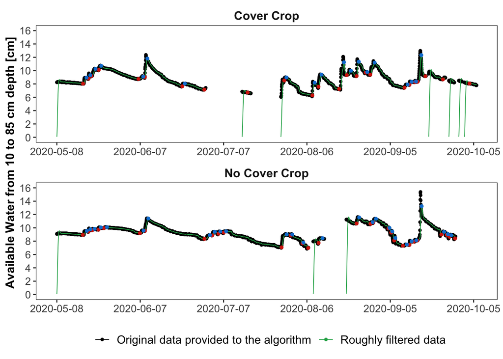

```r
## Import data
data("intermediate.res.butter")

## Format data for plotting
peaks.plot <- merge(butter.peaks, butter.filtered.data, by=c('site', 'treatment', 'chunkid','value'))
peaks.plot$time <- as.POSIXlt(peaks.plot$time, tz='GMT')
butter.filtered.data$time <- as.POSIXlt(butter.filtered.data$time, tz='GMT')
butter.filtered.data$relativetime <- as.numeric(difftime(butter.filtered.data$time, min(butter.filtered.data$time), unit="hours"))+1
peaks.plot$relativetime <- as.numeric(difftime(peaks.plot$time, min(butter.filtered.data$time), unit="hours"))+1


# plot results
ggplot(data=butter.filtered.data, aes(x=relativetime, y=cumul.filter, group=chunkid))+
  geom_line(size=0.5, linetype="dashed")+
  geom_point(size=1, aes(color="Original data provided to the algorithm")) +
  geom_line(size=0.35, linetype = 'solid', aes(y=butter.filter, color="Roughly filtered data"))+
  geom_point(data=peaks.plot[peaks.plot$minormax == 'min',], aes(y=butter.filter), color="#D72809", size=1.15)+
  geom_point(data=peaks.plot[peaks.plot$minormax == 'max',], aes(y=butter.filter), color="#0980D7", size=1.15)+
  ylab("Available Water from 10 to 85 cm depth [cm]")+
  facet_wrap(~treatment, ncol=1, scales="free") +
  scale_color_manual(values=c("black","#25AD57"), name = "")+
  scale_y_continuous(limits=c(0,2*ceiling(max(butter.filtered.data$cumul.filter[!is.na(butter.filtered.data$cumul.filter)]/2))), breaks = seq(-2,2*ceiling(max(butter.filtered.data$cumul.filter[!is.na(butter.filtered.data$cumul.filter)]/2)),by=2))+
  scale_x_continuous(limits=c(1,max(butter.filtered.data$relativetime)), breaks=seq(1,max(butter.filtered.data$relativetime),by=24*30), label = as.Date(as.character(seq(min(butter.filtered.data$time),max(butter.filtered.data$time),by="30 days"))))+
  theme
```

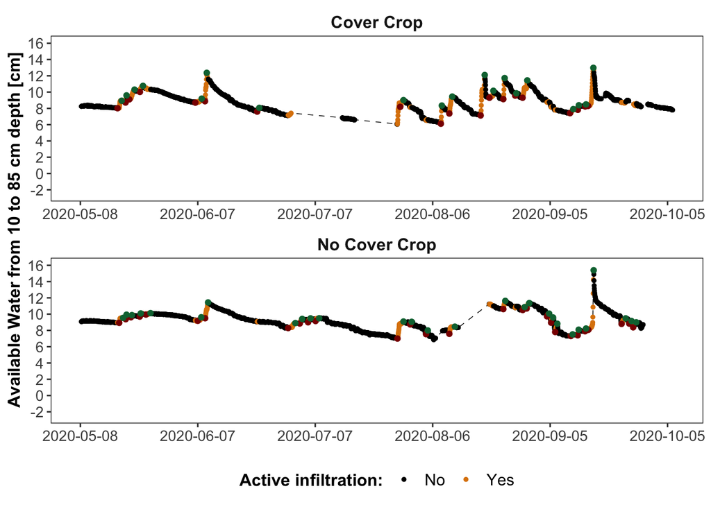

```r
## create dataset for plotting
data.plot <- c()
counter <- 1
for(item in 1:length(filter.chunks1)){ # begin iteration over items
  for (chunk in 1:length(filter.chunks1[[item]])){ # begin iteration over chunks in item

    if(length(data.plot)==0){
      data.plot <- data.frame(filter.chunks1[[item]][chunk])
    } else {
      temp <- data.frame(filter.chunks1[[item]][chunk])
      data.plot <- rbind(data.plot, temp)
    }

  } # end iteration over chunks in item
} # end iteration over items

data.plot$relativetime <- as.numeric(difftime(data.plot$time, min(data.plot$time), unit="hours"))+1 # calculate relative time

peaks1$time.min <- as.POSIXlt(peaks1$time.min, tz='GMT') # convert character into timestamp
peaks1$time.max <- as.POSIXlt(peaks1$time.max, tz='GMT') # convert characcter into timestamp

peaks1$relativetime.min <- as.numeric(difftime(peaks1$time.min, min(data.plot$time), unit="hours"))+1 # calculate relative time
peaks1$relativetime.max <- as.numeric(difftime(peaks1$time.max, min(data.plot$time), unit="hours"))+1

# identify active infiltration
data.plot$active.infiltration <- "No"
for(row in 1:NROW(peaks1)){
  data.plot$active.infiltration[data.plot$relativetime >= peaks1$relativetime.min[row] & data.plot$relativetime <= peaks1$relativetime.max[row]] <- "Yes"
}

# plot results
ggplot(data=data.plot[!is.na(data.plot$cumul.filter),], aes(x=relativetime, y=cumul.filter))+
  geom_line(size=0.25, linetype="dashed")+
  geom_point(size=1, aes(color=active.infiltration)) +
  geom_point(data=peaks1, aes(x=relativetime.min, y = depth.min), color="darkred")+
  geom_point(data=peaks1, aes(x=relativetime.max, y = depth.max), color="#07713F")+
  ylab("Available Water from 10 to 85 cm depth [cm]")+
  facet_wrap(~treatment, ncol=1, scales="free") +
  scale_color_manual(values=c("black","#DD830A"), name="Active infiltration:")+
  scale_y_continuous(limits=c(-2.5,2*ceiling(max(data.plot$cumul.filter[!is.na(data.plot$cumul.filter)]/2))), breaks = seq(-2,2*ceiling(max(data.plot$cumul.filter[!is.na(data.plot$cumul.filter)]/2)),by=2))+
  scale_x_continuous(limits=c(1,max(data.plot$relativetime)), breaks=seq(1,max(data.plot$relativetime),by=24*30), label = as.Date(as.character(seq(min(data.plot$time),max(data.plot$time),by="30 days"))))+
  theme
```